[Edit on GitHub](https://github.com/mbaz/Gaston.jl/blob/master/docs/src/3dplots.md)

# 3-D plotting tutorial

Three dimensional plots can be created with the commands `surf` and `surf!`. These are very similar to plot, except for the `z` coordinate, which is a matrix that specifies the z-coordinate of the points specified in `x` and `y`.

In addition, the following commands are specialized for different types of 3-D plots:

| Command | Purpose |
| --- | --- |
| `scatter3`, `scatter3!` | 3-D point clouds |
| `contour` | Contour plots |
| `heatmap` | Heatmap plots |

## How to plot a set of 3-D coordinates

A set of 3-D coordinates may be explicitly given. Plotting them is just a matter of providing the data to gnuplot. Note that the data may be plotted as a wireframe (with plot style `lines`, which is the default), or as a surface (`pm3d`) with an optional palette.

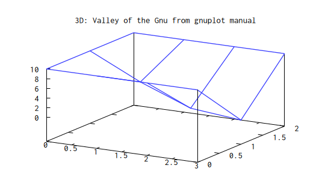

```julia
# plot a wireframe
x = [0,1,2,3]
y = [0,1,2]
z = [10 10 10 10 ; 10 5 1 0 ; 10 10 10 10]
surf(x, y, z,
     Axes(title = "'3D: Valley of the Gnu from gnuplot manual'"))
```

Note that the matrix of `z` coordinates is defined so that the columns are indexed by the `x` coordinates. In other words, `z[1,1]` is the surface at `x = 0, y = 0` and `z[3,1]` is the coordinate at `x = 0, y = 2`.

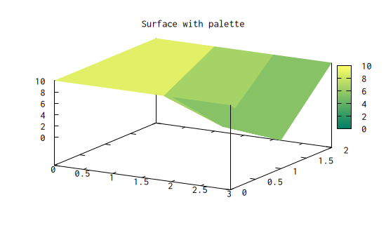

```julia
surf(x, y, z, w = :pm3d,
     Axes(title = "'Surface with palette'",
          palette = :summer))
```

## How to plot a 3-D function

A 3-D function defines a surface for a given set of `x` and `y` samples. Consider the function `(x,y) -> @. sin(sqrt(x*x+y*y))/sqrt(x*x+y*y)`. It may be plotted with

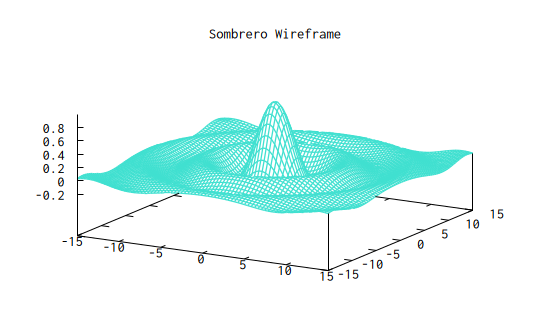

```julia
x = y = -15:0.4:15
f1 = (x,y) -> @. sin(sqrt(x*x+y*y))/sqrt(x*x+y*y)
surf(x, y, f1, lc = :turquoise,
     Axes(title    = :Sombrero_Wireframe,
          hidden3d = :on))
```

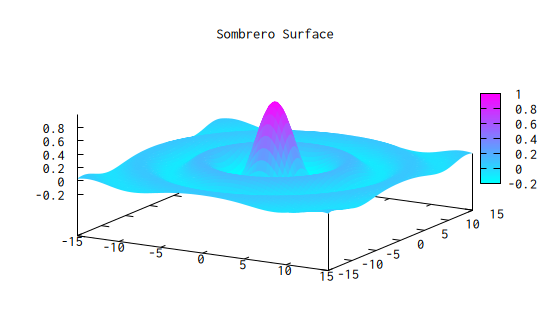

```julia
surf(x, y, f1, w = :pm3d,
     Axes(title    = :Sombrero_Surface,
          palette  = :cool,
          cbrange  = (-0.2, 1),
          hidden3d = :on))
```

## Plotting multiple surfaces with `surf!`

The equivalent to `plot!` is `surf!`:

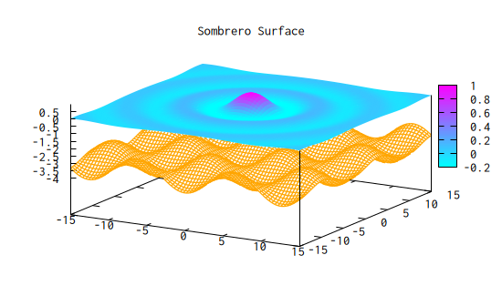

```julia
surf!(x, y , (x,y) -> cos.(x./2).*sin.(y./2)-3, lc = :orange, w = :l)
```

## Plotting contours

Gnuplot's contour support is quite flexible. The `contour` command sets up pretty generic contours, which hopefully are useful in many cases. For much more detail, see gnuplot's documentation.

The contours of a surface can be plotted using:

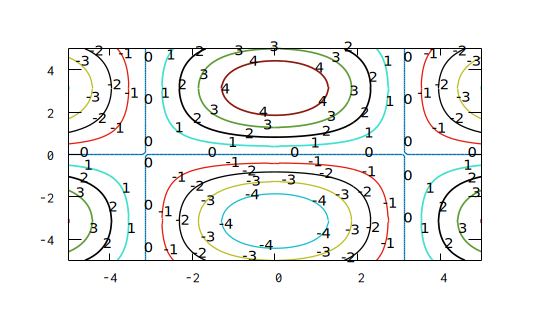

```julia
x = y = -5:0.1:5
contour(x, y, (x,y) -> 5cos.(x/2).*sin.(y/2))
```

The labels can be disabled if `labels=false` is passed as an argument:

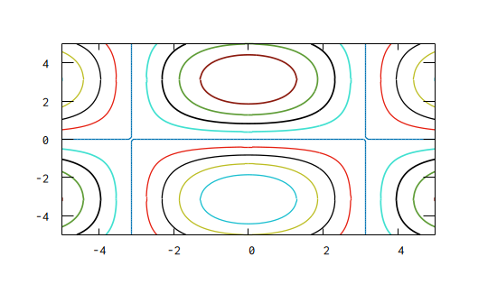

```julia
contour(x, y, (x,y) -> 5cos.(x/2).*sin.(y/2), labels=false)
```

## Plotting heatmaps

Heatmaps can be plotted using `heatmap`. Just like `contour`, this command sets up a pretty basic heatmap; for more control, see gnuplot's documentation.

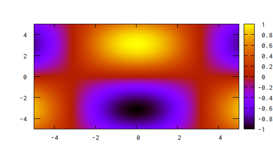

```julia
heatmap(x, y, (x,y)->cos.(x/2).*sin.(y/2))
```